# Нейронная сеть: прогноз временных рядов и оценка аномалий

## Импорт библиотек

```python
import pandas as pd
import numpy as np
import matplotlib.pyplot as plt
import datetime
```

## 1 Загрузка и обработка данных

#### Исходные данные:

Дата-время, количества пассажиров JetRail, нового высокоскоростного железнодорожного сообщения от Unicorn Investors. Нам предоставляются данные за 2 года (август 2012 г. - сентябрь 2014 г.), и с помощью этих данных мы должны прогнозировать количество пассажиров на ближайшие 7 месяцев.

#### Исследуемое подмножество набора данных (август 2012 г. - декабрь 2013 г.)

Создание обучающего и тестового файла для моделирования. Первые 14 месяцев (август 2012 г. - октябрь 2013 г.) используются в качестве данных обучения, а следующие 2 месяца (ноябрь 2013 г. - декабрь 2013 г.) - данные тестирования.

#### После этого: агрегирование набора данных по дням

### 1.1 Загрузка подмножества данных (11856 строчек)

```python
df = pd.read_csv('data/JetRail Traffic Data - Train.csv', nrows = 11856)
df.info()
```

```
<class 'pandas.core.frame.DataFrame'>
RangeIndex: 11856 entries, 0 to 11855
Data columns (total 3 columns):
ID          11856 non-null int64
Datetime    11856 non-null object
Count       11856 non-null int64
dtypes: int64(2), object(1)
memory usage: 278.0+ KB
```

```python
df.head()
```

|  | ID | Datetime | Count |
| --- | --- | --- | --- |
| 0 | 0 | 25-08-2012 00:00 | 8 |
| 1 | 1 | 25-08-2012 01:00 | 2 |
| 2 | 2 | 25-08-2012 02:00 | 6 |
| 3 | 3 | 25-08-2012 03:00 | 2 |
| 4 | 4 | 25-08-2012 04:00 | 2 |

### 1.2 Разбиение на тренировочную и проверочную выборки

```python
train = df[0:10392]
test = df[10392:]
```

### 1.3 Агрегирование данных по ежедневному уровню

##### Выделим даты из Datetime в нужном формате, создадим для них колонку Timestamp

```python
df['Timestamp'] = pd.to_datetime(df['Datetime'],format='%d-%m-%Y %H:%M')
```

```python
df.head()
```

|  | ID | Datetime | Count | Timestamp |
| --- | --- | --- | --- | --- |
| 0 | 0 | 25-08-2012 00:00 | 8 | 2012-08-25 00:00:00 |
| 1 | 1 | 25-08-2012 01:00 | 2 | 2012-08-25 01:00:00 |
| 2 | 2 | 25-08-2012 02:00 | 6 | 2012-08-25 02:00:00 |
| 3 | 3 | 25-08-2012 03:00 | 2 | 2012-08-25 03:00:00 |
| 4 | 4 | 25-08-2012 04:00 | 2 | 2012-08-25 04:00:00 |

```python
df.Timestamp.head()
```

```
0   2012-08-25 00:00:00
1   2012-08-25 01:00:00
2   2012-08-25 02:00:00
3   2012-08-25 03:00:00
4   2012-08-25 04:00:00
Name: Timestamp, dtype: datetime64[ns]
```

##### Превратим новую колонку TimeStamp в индекс нашего dataframe (фрагмента данных)

```python
df.index = df.Timestamp
```

```python
df.head()
```

| Timestamp | ID | Datetime | Count | Timestamp |
| --- | --- | --- | --- | --- |
| 2012-08-25 00:00:00 | 0 | 25-08-2012 00:00 | 8 | 2012-08-25 00:00:00 |
| 2012-08-25 01:00:00 | 1 | 25-08-2012 01:00 | 2 | 2012-08-25 01:00:00 |
| 2012-08-25 02:00:00 | 2 | 25-08-2012 02:00 | 6 | 2012-08-25 02:00:00 |
| 2012-08-25 03:00:00 | 3 | 25-08-2012 03:00 | 2 | 2012-08-25 03:00:00 |
| 2012-08-25 04:00:00 | 4 | 25-08-2012 04:00 | 2 | 2012-08-25 04:00:00 |

##### Применим метод resample для того, чтобы усреднить данные по дням

```python
df = df.resample('D').mean()
```

```python
df.head()
```

| Timestamp | ID | Count |
| --- | --- | --- |
| 2012-08-25 | 11.5 | 3.166667 |
| 2012-08-26 | 35.5 | 3.666667 |
| 2012-08-27 | 59.5 | 2.583333 |
| 2012-08-28 | 83.5 | 2.416667 |
| 2012-08-29 | 107.5 | 2.500000 |

#### То же самое сделаем для тренировочной и проверочной выборок

```python
train['Timestamp'] = pd.to_datetime(train['Datetime'],format='%d-%m-%Y %H:%M')
train.index = train['Timestamp']
train = train.resample('D').mean()
```

```python
test['Timestamp'] = pd.to_datetime(test['Datetime'],format='%d-%m-%Y %H:%M')
test.index = test['Timestamp']
test = test.resample('D').mean()
```

```python
train.head()
```

| Timestamp | ID | Count |
| --- | --- | --- |
| 2012-08-25 | 11.5 | 3.166667 |
| 2012-08-26 | 35.5 | 3.666667 |
| 2012-08-27 | 59.5 | 2.583333 |
| 2012-08-28 | 83.5 | 2.416667 |
| 2012-08-29 | 107.5 | 2.500000 |

```python
test.head()
```

| Timestamp | ID | Count |
| --- | --- | --- |
| 2013-11-01 | 10403.5 | 161.583333 |
| 2013-11-02 | 10427.5 | 103.083333 |
| 2013-11-03 | 10451.5 | 76.833333 |
| 2013-11-04 | 10475.5 | 156.416667 |
| 2013-11-05 | 10499.5 | 169.750000 |

##### Регистрируем конвертеры даты-времени для matplotlib

```python
from pandas.plotting import register_matplotlib_converters
register_matplotlib_converters()
```

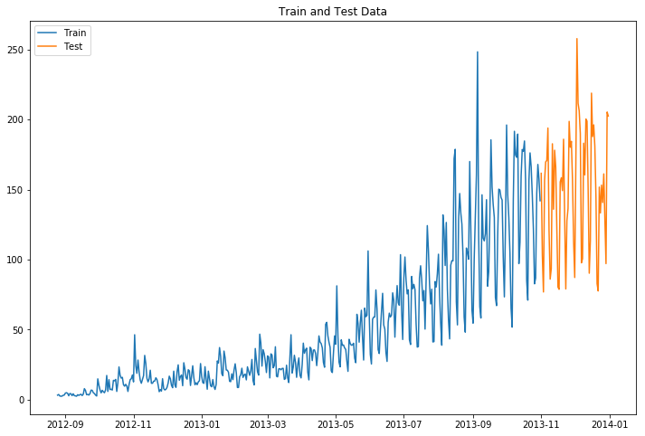

```python
plt.figure(figsize=(12,8))
plt.title("Train and Test Data")
plt.plot(train.index, train['Count'], label='Train')
plt.plot(test.index,test['Count'], label='Test')
plt.legend(loc='best')
plt.show()
```

# 3 Нейронная сеть

### Импортируем модуль keras для создания нейронной сети

```python
import tensorflow.keras
from tensorflow.keras.models import Sequential
from tensorflow.keras.layers import Dense
```

### Инициализация нейронной сети

```python
model = Sequential()
```

### Добавляем слои

```python
model.add(Dense(units = 128,  activation = 'relu', input_dim = 64))
model.add(Dense(units = 64,  activation = 'relu'))
model.add(Dense(units = 32,  activation = 'relu'))
model.add(Dense(units = 8,  activation = 'relu'))
model.add(Dense(units = 1, activation = 'relu'))
```

### Компилируем нейронную сеть

```python
model.compile(optimizer='adam', loss='mse')
```

# 4 Применение для выявления аномалий в тренировочной выборке

### Задаем количество дней, по которым будем вычислять прогноз (длину окна): должно совпадать с количеством входов нейронной сети (input_dim первого слоя)

```python
window_size = 64
```

### Задаем количество окон (каждое длиной days_for_predict), которое используется для обучения нейронной сети

```python
number_of_windows = 64
```

```python
y_hat = train.copy()
```

```python
y_hat['NN'] = train['Count'][0]
```

### Алгоритм обучения и прогноза

1. Выбираем первое окно длиной window_size, складываем его в стопку.
2. Смещаем окно на единицу, складываем в стопку
3. И так number_of_windows раз. Стопка из number_of_windows массивов длиной window_size используется для обучения нейронной сети и прогноза значения после последнего окна
4. После этого вычисления повторяются со смещением на одно значение вперед.

Пример: window_size = 32, number_of_windows = 32

Шаг 1: начиная с первого значения окно длиной 32 значения смещается 32 раза и используется для прогноза 65 значения.

Шаг 2: начиная со второго значения окно длиной 32 значения смещается 32 раза и используется для прогноза 66 значения. и т.д.

##### Пример первой стопки

```python
for i in range(0, number_of_windows):
    # print('Окно от ', i, 'до ', i+window_size)
    # print('Значения для обучения модели:', train[i:i+window_size])
    if i ==0:
        nn_input = train[i:i+window_size]['Count'].values
        # print(nn_input)
    else:
        # print(train[i:i+window_size]['Count'].values)
        nn_input = np.vstack((nn_input,train[i:i+window_size]['Count'].values))
```

### Вход первой стопки

```python
print(nn_input)
```

```
[[ 3.16666667  3.66666667  2.58333333 ... 10.91666667  9.66666667
   5.83333333]
 [ 3.66666667  2.58333333  2.41666667 ...  9.66666667  5.83333333
  10.66666667]
 [ 2.58333333  2.41666667  2.5        ...  5.83333333 10.66666667
  14.25      ]
 ...
 [10.91666667  9.66666667  5.83333333 ... 15.66666667 10.58333333
  12.08333333]
 [ 9.66666667  5.83333333 10.66666667 ... 10.58333333 12.08333333
  10.66666667]
 [ 5.83333333 10.66666667 14.25       ... 12.08333333 10.66666667
  12.66666667]]
```

##### Выход первой стопки для обучения

```python
nn_output = train['Count'][window_size:window_size+number_of_windows].values.reshape(-1,1)
```

```python
nn_output.T
```

```
array([[10.66666667, 14.25      , 14.91666667, 17.58333333, 12.66666667,
        46.33333333, 24.33333333, 18.75      , 28.25      , 19.75      ,
        13.91666667, 11.66666667, 14.5       , 17.16666667, 31.58333333,
        25.83333333, 15.25      , 12.66666667, 14.83333333, 21.        ,
        11.66666667, 11.66666667, 13.16666667, 13.25      , 15.58333333,
        14.33333333, 10.66666667,  5.66666667,  7.16666667,  6.08333333,
        14.91666667,  7.91666667,  6.91666667,  7.33333333,  8.75      ,
        11.83333333, 16.75      , 14.83333333, 10.16666667,  8.5       ,
        20.33333333, 10.58333333,  8.75      , 19.91666667, 24.83333333,
        13.83333333, 16.5       , 17.58333333,  9.91666667, 26.33333333,
        21.91666667, 15.66666667, 14.58333333, 21.33333333, 20.58333333,
        10.08333333, 17.41666667, 24.16666667, 15.66666667, 10.58333333,
        12.08333333, 10.66666667, 12.66666667, 13.5       ]])
```

##### Обучение нейронной сети

```python
model.fit(nn_input, nn_output, batch_size = 8, epochs = 5, verbose=1, validation_split = 0.1)
```

```
Train on 57 samples, validate on 7 samples
```

```
<tensorflow.python.keras.callbacks.History at 0x27886a72160>
```

##### Прогноз для значения после последнего окна (по новой стопке)

```python
new_base = train[0+number_of_windows:0+number_of_windows+window_size]['Count'].values.reshape(1,-1)
```

```python
new_base
```

```
array([[10.66666667, 14.25      , 14.91666667, 17.58333333, 12.66666667,
        46.33333333, 24.33333333, 18.75      , 28.25      , 19.75      ,
        13.91666667, 11.66666667, 14.5       , 17.16666667, 31.58333333,
        25.83333333, 15.25      , 12.66666667, 14.83333333, 21.        ,
        11.66666667, 11.66666667, 13.16666667, 13.25      , 15.58333333,
        14.33333333, 10.66666667,  5.66666667,  7.16666667,  6.08333333,
        14.91666667,  7.91666667,  6.91666667,  7.33333333,  8.75      ,
        11.83333333, 16.75      , 14.83333333, 10.16666667,  8.5       ,
        20.33333333, 10.58333333,  8.75      , 19.91666667, 24.83333333,
        13.83333333, 16.5       , 17.58333333,  9.91666667, 26.33333333,
        21.91666667, 15.66666667, 14.58333333, 21.33333333, 20.58333333,
        10.08333333, 17.41666667, 24.16666667, 15.66666667, 10.58333333,
        12.08333333, 10.66666667, 12.66666667, 13.5       ]])
```

```python
model.predict(new_base)[0]
```

```
array([22.020407], dtype=float32)
```

```python
train['Count'][i+window_size]
```

```
13.5
```

### Все стопки

##### Массив для аномальных значений

```python
z_hat = train.copy()
```

##### Обучение нейронной сети по предыдущей стопке, прогноз значения и вычисление аномалий

```python
for i in range(0,len(train) - window_size - number_of_windows):
    for j in range(i, i + number_of_windows):
        if j ==i:
            nn_input = train[j:j+window_size]['Count'].values
        else:
            nn_input = np.vstack((nn_input,train[j:j+window_size]['Count'].values))
    nn_output = train['Count'][i+window_size:i+window_size+number_of_windows].values.reshape(-1,1)
    model.fit(nn_input, nn_output, batch_size = 128, epochs = 10, verbose=0, validation_split = 0.1)
    new_base = train[i+number_of_windows:i+number_of_windows+window_size]['Count'].values.reshape(1,-1)
    y_hat['Count'][i+window_size+number_of_windows] = model.predict(new_base)[0]
    # print(abs(model.predict(new_base)[0]-train['Count'][i+number_of_windows+window_size]))
    if abs(model.predict(new_base)[0]-train['Count'][i+number_of_windows+window_size]) < 30:
        z_hat['Count'][i+number_of_windows+window_size]=np.NaN
print('Прогноз построен, аномалии вычислены')
```

```
Прогноз построен, аномалии вычислены
```

##### Из массива аномальных значений удаляем значения, которые не прогнозировались нейронной сетью

```python
for i in range(0, window_size + number_of_windows):
    z_hat['Count'][i] = np.NaN
```

### Графики: тренировочной выборки, прогноза нейронной сети и аномалий

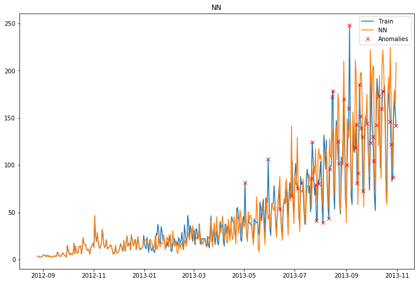

```python
plt.figure(figsize=(12,8))
plt.plot(train.index,train['Count'], label='Train')
plt.plot(y_hat.index,y_hat['Count'], label='NN')
plt.plot(z_hat.index,z_hat['Count'], 'rx', label='Anomalies')
plt.legend(loc='best')
plt.title("NN")
plt.show()
```

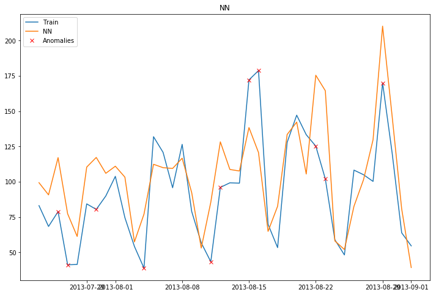

```python
plt.figure(figsize=(12,8))
plt.plot(train.index[-100:-60],train['Count'][-100:-60], label='Train')
plt.plot(y_hat.index[-100:-60],y_hat['Count'][-100:-60], label='NN')
plt.plot(z_hat.index[-100:-60],z_hat['Count'][-100:-60], 'rx', label='Anomalies')
plt.legend(loc='best')
plt.title("NN")
plt.show()
```

### Выведем список аномальных значений

```python
z_hat.dropna()
```

| Timestamp | ID | Count |
| --- | --- | --- |
| 2013-05-02 | 6011.5 | 81.250000 |
| 2013-05-30 | 6683.5 | 106.166667 |
| 2013-06-13 | 7019.5 | 53.333333 |
| 2013-06-27 | 7355.5 | 67.333333 |
| 2013-07-04 | 7523.5 | 75.500000 |
| 2013-07-21 | 7931.5 | 86.000000 |
| 2013-07-22 | 7955.5 | 124.250000 |
| 2013-07-26 | 8051.5 | 78.833333 |
| 2013-07-27 | 8075.5 | 41.166667 |
| 2013-07-30 | 8147.5 | 80.416667 |
| 2013-08-04 | 8267.5 | 38.833333 |
| 2013-08-11 | 8435.5 | 43.333333 |
| 2013-08-12 | 8459.5 | 96.000000 |
| 2013-08-15 | 8531.5 | 172.166667 |
| 2013-08-16 | 8555.5 | 178.750000 |
| 2013-08-22 | 8699.5 | 125.250000 |
| 2013-08-23 | 8723.5 | 102.000000 |
| 2013-08-29 | 8867.5 | 170.000000 |
| 2013-09-02 | 8963.5 | 100.333333 |
| 2013-09-04 | 9011.5 | 160.583333 |
| 2013-09-05 | 9035.5 | 248.333333 |
| 2013-09-12 | 9203.5 | 118.500000 |
| 2013-09-13 | 9227.5 | 142.750000 |
| 2013-09-14 | 9251.5 | 81.000000 |
| 2013-09-15 | 9275.5 | 91.250000 |
| 2013-09-17 | 9323.5 | 185.500000 |
| 2013-09-18 | 9347.5 | 151.833333 |
| 2013-09-19 | 9371.5 | 139.250000 |
| 2013-09-20 | 9395.5 | 130.083333 |
| 2013-09-21 | 9419.5 | 72.916667 |
| 2013-09-26 | 9539.5 | 144.333333 |
| 2013-09-30 | 9635.5 | 123.833333 |
| 2013-10-03 | 9707.5 | 129.916667 |
| 2013-10-04 | 9731.5 | 104.750000 |
| 2013-10-07 | 9803.5 | 142.166667 |
| 2013-10-10 | 9875.5 | 173.000000 |
| 2013-10-14 | 9971.5 | 159.666667 |
| 2013-10-15 | 9995.5 | 178.583333 |
| 2013-10-24 | 10211.5 | 146.000000 |
| 2013-10-25 | 10235.5 | 121.750000 |
| 2013-10-27 | 10283.5 | 86.750000 |
| 2013-10-31 | 10379.5 | 142.000000 |